# Practical Machine Learning: assignment

JM

08/01/2017

# Loading and data preparation

```r
library(data.table)
library(caret)
library(randomForest)
```

```r
library(rpart.plot)
library(rattle)
training = fread('https://d396qusza40orc.cloudfront.net/predmachlearn/pml-training.csv')
testing = fread('https://d396qusza40orc.cloudfront.net/predmachlearn/pml-testing.csv')

training = data.frame(training)
testing = data.frame(testing)

training[training == ""] = NA
testing[testing == ""] = NA
```

The next few steps go on to remove variables that have over 60% NAs. In the end, this simplifies the exercise and reduces many unecessary variables.

```r
x = vector()
for (i in 1:ncol(training)){

  if (sum(is.na(training[,i])) / nrow(training) < .6){

    x[i] = i
  } else {
  x[i] = NA
  }
}
x = na.omit(x)

training = training[,x]
training = training[,8:ncol(training)]
```

Furthermore, we should exclude variables that are highly correlated assuming whatever the variance of one explains so will the variance of another. Again, this simplifies the exercise by removing a few additional variables.

```r
matrix.corr = cor(na.omit(training[sapply(training, is.numeric)]))

removecor = findCorrelation(matrix.corr, cutoff = .90, verbose = TRUE)
```

```
## Compare row 10  and column  1 with corr  0.992
##   Means:  0.27 vs 0.168 so flagging column 10
## Compare row 1  and column  9 with corr  0.925
##   Means:  0.25 vs 0.164 so flagging column 1
## Compare row 9  and column  4 with corr  0.928
##   Means:  0.233 vs 0.161 so flagging column 9
## Compare row 8  and column  2 with corr  0.966
##   Means:  0.245 vs 0.157 so flagging column 8
## Compare row 19  and column  18 with corr  0.918
##   Means:  0.091 vs 0.158 so flagging column 18
## Compare row 46  and column  31 with corr  0.914
##   Means:  0.101 vs 0.161 so flagging column 31
## Compare row 46  and column  33 with corr  0.933
##   Means:  0.083 vs 0.164 so flagging column 33
## All correlations <= 0.9
```

```r
training.reducecorr = training[,-removecor]
```

Additionally, we will split the training set for crossvalidation.

```r
inTrain = createDataPartition(y = training.reducecorr$classe, p=0.7, list = FALSE)
training = training.reducecorr[inTrain,]
validation = training.reducecorr[-inTrain,]
```

# Fitting a regressing tree

We will be using train from the caret package and fitting a regression tree, using the caret package will simplify the exercise.

The final model is displayed below.

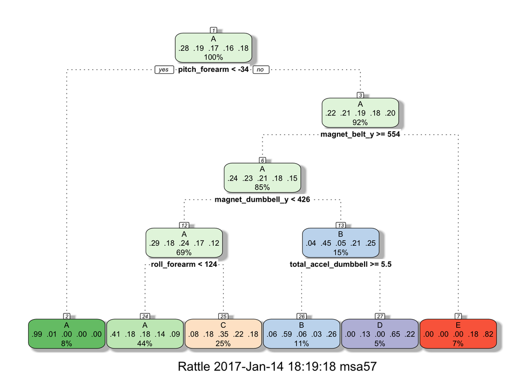

```r
mod.rpart = train(classe~., data = training, method = 'rpart')
print(fancyRpartPlot(mod.rpart$finalModel))
```

Now, how accurate is this model? We use the predict function on the validation set to see how accurate the model is.

```r
pred.rpart = data.frame(rpart = predict(mod.rpart, validation), outcome = validation$classe)

table(pred.rpart$rpart, pred.rpart$outcome)
```

```
##
##        A    B    C    D    E
##   A 1509  450  472  367  223
##   B   33  361   32   18  162
##   C  132  295  521  335  288
##   D    0   33    1  155   53
##   E    0    0    0   89  356
```

From the table above we can see that it isn’t very accurate. We can make some simple calculations to get to the % of correct predictions and see it gets about half right.

```r
sum(pred.rpart$rpart == pred.rpart$outcome)/nrow(pred.rpart)
```

```
## [1] 0.4931181
```

# Random Forest

Now let’s try a random forest before we go on to compare the two models.

```r
mod.rf = train(classe~., data = training, method = 'rf')
mod.rf$finalModel
```

```
##
## Call:
##  randomForest(x = x, y = y, mtry = param$mtry)
##                Type of random forest: classification
##                      Number of trees: 500
## No. of variables tried at each split: 23
##
##         OOB estimate of  error rate: 0.68%
## Confusion matrix:
##      A    B    C    D    E class.error
## A 3900    6    0    0    0 0.001536098
## B   19 2629    9    1    0 0.010910459
## C    0   15 2375    6    0 0.008764608
## D    0    0   24 2224    4 0.012433393
## E    0    0    3    6 2516 0.003564356
```

```r
ose=predict(mod.rf,validation,type="raw")
ose.matrix = with(validation,table(ose,classe))
sum(diag(ose.matrix))/sum(as.vector(ose.matrix))
```

```
## [1] 0.9938828
```

# Comparing the models

We can now look at how effective each of these models is. From the table below we can tell that the random forest predicts around 99% accurately whilst the regression tree only gets about 50%.

```r
pred = data.frame(rpart = predict(mod.rpart, validation), rf = predict(mod.rf, validation), outcome = validation$classe)

rpart.accuracy = sum(pred$rpart == pred$outcome)/nrow(pred)
rf.accuracy = sum(pred$rf == pred$outcome)/nrow(pred)

accuracy = data.frame(rpart.accuracy,rf.accuracy)
print(accuracy)
```

```
##   rpart.accuracy rf.accuracy
## 1      0.4931181   0.9938828
```

# Conclusion

Having seen that the random forest is quite accurate we go on to apply it to the testing set.

```r
predict(mod.rf, testing)
```

```
##  [1] B A B A A E D B A A B C B A E E A B B B
## Levels: A B C D E
```